# FOMO Marketing

Molly Tseng

Marketing Psychology · 2026

*FOMO*  
Marketing

The Psychology of Now

Consumer Psychology Behavioral Marketing Digital Strategy

## What is FOMO?

"The uneasy feeling that others might be having rewarding experiences from which one is absent." — Przybylski et al., 2013 · Motivation and Emotion Journal

69%

of millennials experience FOMO regularly

60%

make reactive purchases because of FOMO

33%

feel anxious when unable to check social media

## The psychology behind FOMO

Cognitive trigger chain

Scarcity cue

People notice that something may run out soon

↓

Loss aversion activates

People hate missing out more than they enjoy gaining something

↓

Anxiety & social comparison

People begin comparing themselves to others and feel pressure to act

↓

Impulse action

People make quick decisions before they have time to think carefully

## 4 FOMO triggers

01 · Time scarcity

Countdown timers shrink the decision window, forcing fast emotional choices over deliberate ones.

"Offer ends in 02:47:13"

02 · Supply scarcity

Low stock signals amplify loss aversion — rarity makes inaction feel riskier than buying.

"Only 3 left in stock"

03 · Social proof

Real-time activity creates conformity pressure and reduces perceived risk of the purchase.

"12 people viewing this now"

04 · Exclusivity

Gated access triggers status anxiety — belonging to the in-group becomes the reward itself.

"Members get 30-min early access"

## How brands use FOMO

Booking.com

Stacks time pressure, scarcity, and social proof on every listing — making every room feel like a last chance.

[figure not shown]

Amazon

Prime Day turned scarcity into a cultural moment. Progress bars and countdowns create a game-like urgency loop.

[figure not shown]

Airbnb

"Rare find" badges reframe ordinary listings as exceptional — a double-sided FOMO play for hosts and guests.

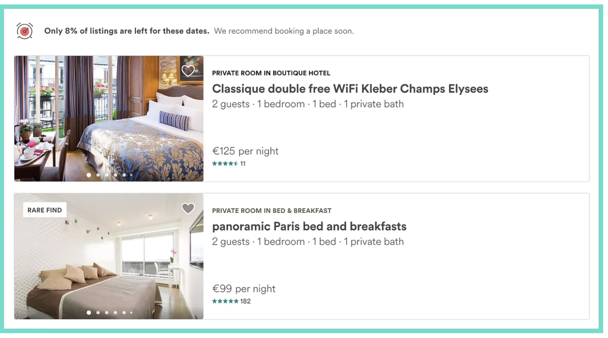

"Rare find · This property is usually fully booked"

## How to use FOMO ethically

**Be truthful about scarcity**If something isn’t actually limited, don’t pretend it is. Fake urgency can quickly damage customer trust.

**Target the already-interested**Use FOMO with people already interested in the product instead of forcing it on everyone.

**Use sparingly — reserve for key moments**Too much urgency stops feeling special. Save it for important launches or limited releases.

**Lead with value, not fear**Good marketing starts with a good product. FOMO should support value, not replace it.

## FOMO vs. JOMO

FOMO

Fear of Missing Out

Driven by urgency, scarcity, and social pressure. Consumers rush to act because they don’t want to miss out.

“Buy now before it’s gone.”

VS

JOMO

Joy of Missing Out

Focused on intentional choices and emotional balance. Consumers think more carefully instead of buying things impulsively.

“I don’t need every trend.”

Modern consumers are shifting from constant urgency toward more mindful and intentional behavior.

## Data & Resources

ThimPress. (2024).  
*FOMO Marketing: How Fear of Missing Out Drives Consumer Behavior.*  
https://thimpress.com/fomo-marketing/

Mailchimp. (2024).  
*FOMO Marketing: What It Is and How to Use It Effectively.*  
https://mailchimp.com/resources/fomo-marketing/

Booking.com, Amazon, and Airbnb interface examples used for educational analysis purposes.

Thank you

Questions?

FOMO Marketing · The Psychology of Now

Consumer Psychology Behavioral Marketing Digital Strategy